# Reproducible Research Assignment 1

Nick Campono

6/30/2020

```r
library(ggplot2)
library(lubridate)
```

The variables included in this dataset are:

steps: Number of steps taking in a 5-minute interval (missing values are coded as NA)

date: The date on which the measurement was taken in YYYY-MM-DD format

interval: Identifier for the 5-minute interval in which measurement was taken

## First step read in the data

```r
activity.data<-read.csv("C:/Users/ncampono/Desktop/R/Courses/Reproducible Research/Peer Assignments/activity.csv")

str(activity.data)
```

```
## 'data.frame':    17568 obs. of  3 variables:
##  $ steps   : int  NA NA NA NA NA NA NA NA NA NA ...
##  $ date    : Factor w/ 61 levels "2012-10-01","2012-10-02",..: 1 1 1 1 1 1 1 1 1 1 ...
##  $ interval: int  0 5 10 15 20 25 30 35 40 45 ...
```

## What is mean total number of steps taken per day?

For this part of the assignment, you can ignore the missing values in the dataset. Make a histogram of the total number of steps taken each day

```r
steps.per.day<-aggregate(steps ~ date , data = activity.data, sum)

head(steps.per.day)
```

```
##         date steps
## 1 2012-10-02   126
## 2 2012-10-03 11352
## 3 2012-10-04 12116
## 4 2012-10-05 13294
## 5 2012-10-06 15420
## 6 2012-10-07 11015
```

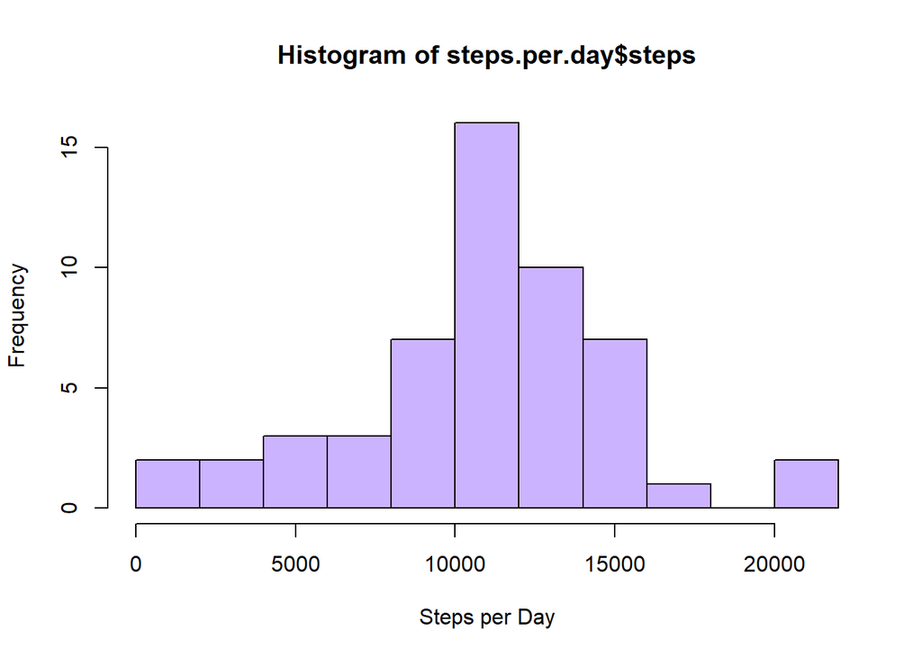

```r
hist(steps.per.day$steps, col = '#ccb3ff', breaks =10, xlab = "Steps per Day", ylab = "Frequency")
```

Calculate and report the mean and median total number of steps taken per day

```r
spd.median<- median(steps.per.day$steps)
print(spd.median)
```

```
## [1] 10765
```

```r
spd.mean<-mean(steps.per.day$steps)
print(spd.mean)
```

```
## [1] 10766.19
```

mean = 10766.19 median = 10765

## What is the average daily activity pattern?

Make a time series plot (i.e. type = “l”) of the 5-minute interval (x-axis) and the average number of steps taken, averaged across all days (y-axis)

```r
daily.pattern<-aggregate(steps ~ interval , data = activity.data, mean)

head(daily.pattern)
```

```
##   interval     steps
## 1        0 1.7169811
## 2        5 0.3396226
## 3       10 0.1320755
## 4       15 0.1509434
## 5       20 0.0754717
## 6       25 2.0943396
```

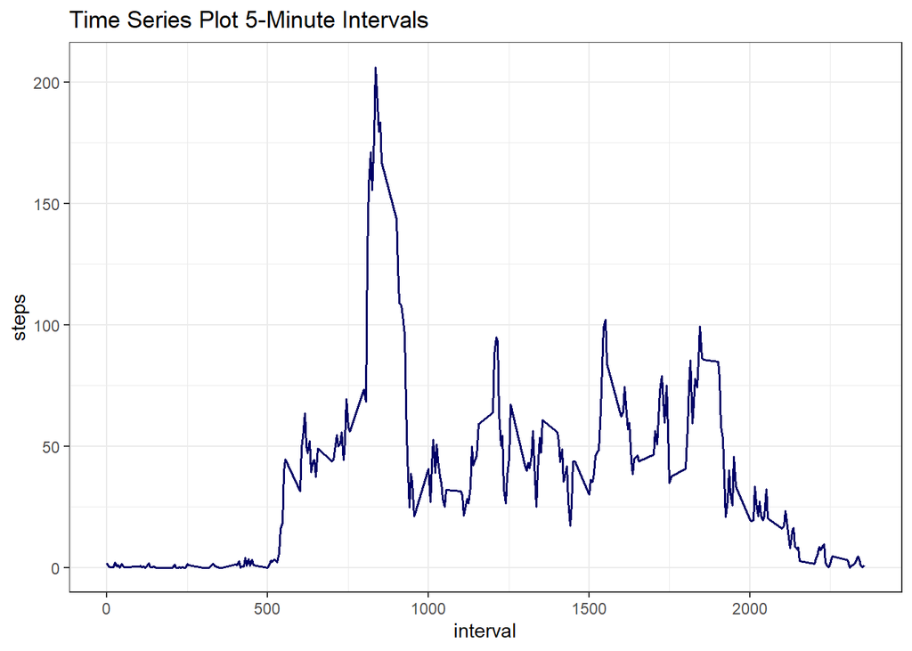

```r
ggplot(daily.pattern, aes(interval, steps)) + geom_line(size = 0.65, color = '#000066') + theme_bw() + ggtitle("Time Series Plot 5-Minute Intervals")
```

Which 5-minute interval, on average across all the days in the dataset, contains the maximum number of steps?

```r
daily.pattern[which.max(daily.pattern$steps),]
```

```
##     interval    steps
## 104      835 206.1698
```

## Imputing missing values

Note that there are a number of days/intervals where there are missing values (coded as NA). The presence of missing days may introduce bias into some calculations or summaries of the data.

```r
colSums(is.na(activity.data))
```

```
##    steps     date interval
##     2304        0        0
```

```r
na.steps<-sum(is.na(activity.data$steps))

total.activity<-nrow(activity.data)

na.steps/total.activity
```

```
## [1] 0.1311475
```

2304 step values are null, 13.11% of the rows

Create a new dataset that is equal to the original dataset but with the missing data filled in.

```r
avg.steps<- mean(activity.data$steps , na.rm = TRUE)

activity.data.mean<- activity.data

activity.data.mean$steps[is.na(activity.data.mean$steps)] <- mean(activity.data.mean$steps, na.rm = T)

head(activity.data.mean)
```

```
##     steps       date interval
## 1 37.3826 2012-10-01        0
## 2 37.3826 2012-10-01        5
## 3 37.3826 2012-10-01       10
## 4 37.3826 2012-10-01       15
## 5 37.3826 2012-10-01       20
## 6 37.3826 2012-10-01       25
```

Make a histogram of the total number of steps taken each day in new data set

```r
steps.per.day.mean<-aggregate(steps ~ date , data = activity.data.mean, sum)

head(steps.per.day.mean)
```

```
##         date    steps
## 1 2012-10-01 10766.19
## 2 2012-10-02   126.00
## 3 2012-10-03 11352.00
## 4 2012-10-04 12116.00
## 5 2012-10-05 13294.00
## 6 2012-10-06 15420.00
```

```r
head(steps.per.day.mean)
```

```
##         date    steps
## 1 2012-10-01 10766.19
## 2 2012-10-02   126.00
## 3 2012-10-03 11352.00
## 4 2012-10-04 12116.00
## 5 2012-10-05 13294.00
## 6 2012-10-06 15420.00
```

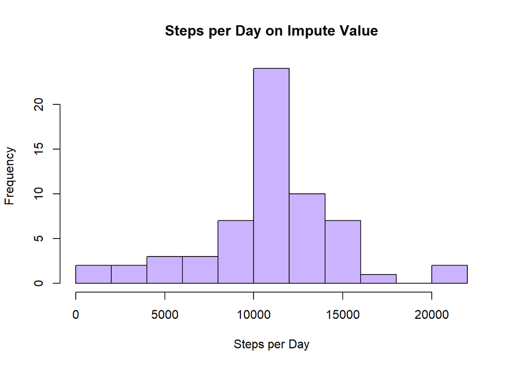

```r
hist(steps.per.day.mean$steps, col = '#ccb3ff', breaks =10, main = "Steps per Day on Impute Value",
     xlab = "Steps per Day", ylab = "Frequency")
```

Calculate and report the mean and median total number of steps taken per day

```r
spdm.median<-median(steps.per.day.mean$steps)
print(spdm.median)
```

```
## [1] 10766.19
```

```r
spdm.mean<-mean(steps.per.day.mean$steps)
print(spdm.mean)
```

```
## [1] 10766.19
```

median = 10766.19 mean = 10766.19

Do these values differ from the estimates from the first part of the assignment? The means are the same and the median is very close. They don’t differ by much at all.

## Are there differences in activity patterns between weekdays and weekends?

Create a new factor variable in the dataset with two levels – “weekday” and “weekend” indicating whether a given date is a weekday or weekend day.

```r
activity.data.mean$date<- as.Date(activity.data.mean$date)
activity.data.mean$weekdays<-weekdays(activity.data.mean$date)
activity.data.mean$weeks[(activity.data.mean$weekdays == "Saturday" | activity.data.mean$weekdays == "Sunday")] <- "weekend"
activity.data.mean$weeks[!(activity.data.mean$weekdays == "Saturday" | activity.data.mean$weekdays == "Sunday")] <- "weekday"
head(activity.data.mean)
```

```
##     steps       date interval weekdays   weeks
## 1 37.3826 2012-10-01        0   Monday weekday
## 2 37.3826 2012-10-01        5   Monday weekday
## 3 37.3826 2012-10-01       10   Monday weekday
## 4 37.3826 2012-10-01       15   Monday weekday
## 5 37.3826 2012-10-01       20   Monday weekday
## 6 37.3826 2012-10-01       25   Monday weekday
```

Make a panel plot containing a time series plot type = 1 of the 5-minute interval (x-axis) and the average number of steps taken, averaged across all weekday days or weekend days (y-axis).

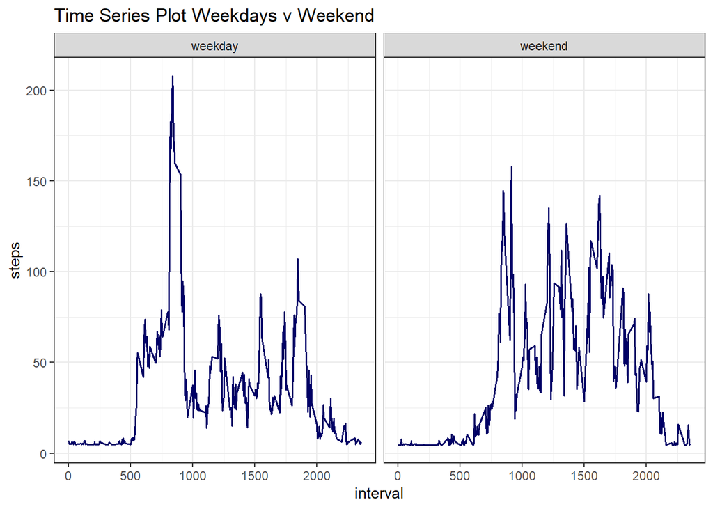

```r
weekdays.pattern<-aggregate(steps ~ interval + weeks, data = activity.data.mean, mean)

ggplot(weekdays.pattern, aes(interval, steps)) + geom_line(size = 0.65, color = '#000066') + theme_bw() +
        ggtitle("Time Series Plot Weekdays v Weekend") + facet_grid(.~weeks)
```

Are there differences in activity patterns between weekdays and weekends? Yes there is a clear pattern difference between weekdays and weekends based on this data